# Modulo 5 | Exercícios

Autor

A. Peralta-Santos

Data de Publicação

16 de outubro de 2024

# 1 Setup

```r
rm(list = ls(all.names = TRUE))
# Packages
required_packages <- c(
                       "assertr",
                       "data.validator",
                       "janitor",
                       "tidyverse",
                       "rio",
                       "data.table",
                       "broom",
                       "gt",
                       "gtsummary",
                       "glm2",
                       "performance",
                       "see"
                       # colocar aqui se foram utilizados mais pacotes
                       )

for (pkg in required_packages) {
  # install packages if not already present
  if (!pkg %in% rownames(installed.packages())) {
    install.packages(pkg)
  }

  # load packages to this current session
  library(pkg, character.only = TRUE)
}
remove(required_packages)
remove(pkg)
```

# 2 Exercício - Hipotermia Cirúrgica

## 2.1 Contexto

A hipotermia cirúrgica (definida como temperatura central < 36°C) é conhecida por causar coagulopatia, alteração no metabolismo de drogas, recuperação prolongada e desconforto térmico. Menos compreendido é se as infecções do sítio cirúrgico (ISCs) também estão associadas à hipotermia intraoperatória.

Isso é importante, pois as infecções do sítio cirúrgico são uma grande fonte de morbidade, mortalidade, prolongamento da hospitalização e custos de saúde. O risco geral de ISC é de 1 a 3%, geralmente, mas é substancialmente maior, 10 a 15%, para pacientes submetidos à cirurgia colorretal.

Literatura publicada até a data sugere que a hipotermia moderada causa ISCs e várias outras complicações. No entanto, alguns desses estudos estão desatualizados (os procedimentos cirúrgicos descritos já não são realizados) e muitos não possuem dados suficientes de temperatura intraoperatória. Portanto, é desconhecido se a hipotermia leve ou temperaturas normotérmicas influenciam o risco de infecção. [^1]

## 2.2 Objetivo

Avaliar a relação entre a média ponderada do tempo (TWATemp) da temperatura central e as infecções graves de feridas e sistêmicas que se desenvolvem dentro de 30 dias após a cirurgia colorretal, no geral e após levar em conta as informações de covariáveis.

## 2.3 Instruções

### 2.3.1 Dataset

Use o dataset Core_Temperature.xlsx, e consulte a documentação em Core_Temperature_Data_Dictionary2.pdf na pasta de datasets. O objetivo geral do exercício é avaliar o efeito da temperatura (TWATemp) no risco de ISCs (AnyInfection).

1. Importar para um objeto “temperature_data” com o dataset
2. Limpar o nome das variáveis

```r
temperature_data <- import("datasets/Core_Temperature.xlsx") |>
  clean_names() |>
  mutate(
   any_infection = factor(
     any_infection,
     levels = c(0,1),
     labels = c("Não", "Sim")
   )
  )
```

### 2.3.2 Exercicio M5.1 Estatística Descritiva

Deve criar uma Tabela 1 comparando a distribuição das variáveis de confundimento (Age, FEMALE, BMI, CharlsonScore, SurgeryType, CHF) pelos pacientes que tiveram ISC (AnyInfection).

1. O nome do objeto deve ser tabela 1

```r
tabela1 <- tbl_summary(
  temperature_data,
  include = c(age, female, bmi, charlson_score, surgery_type), # Selecionar variáveis específicas para o resumo
  by = any_infection, # Dividir a tabela pelo estado da doença cardíaca
  missing = "no",# Excluir dados ausentes do resumo
  statistic = list(
  all_continuous() ~ "{mean} ({sd})",
  all_categorical() ~ "{n} / {N} ({p}%)"),
  label =list(
    age= "Idade",
    female="Sexo",
    bmi="Índice de Massa Corporal",
    charlson_score="Score de Charlson",
    surgery_type="Tipo de Cirugia"
  )
) |>
  modify_spanning_header(c("stat_1", "stat_2") ~ "**Infecção do Sítio Cirúrgico**") %>%
  add_n() |>  # Adicionar uma coluna para contar observações não ausentes
  add_p() |>  # Realizar testes estatísticos para comparar grupos
  modify_header(label = "**Característica**") |>  # Personalizar o cabeçalho da tabela
  bold_labels()|> # Tornar as etiquetas em negrito para ênfase
  as_gt() |>
  tab_header(
    title = md("**Modelo de Risco para Infecção do Sítio cirúrgico**") ,
    subtitle = "Por Idade, Sexo, BMI, Score Charlson, Tipo de cirurgia"
  ) |>
  tab_source_note(
    source_note = md("Source: Core Temperature Dataset")
  ) |>
  fmt_number( decimals = 3) |>
  opt_stylize(style = 1, color = "gray") |>
  opt_align_table_header(align = "left")

# Visualizar a tabela criada
tabela1
```

**Modelo de Risco para Infecção do Sítio cirúrgico**

Por Idade, Sexo, BMI, Score Charlson, Tipo de cirurgia

| **Característica** | **N** | **Infecção do Sítio Cirúrgico** **Não** N = 6,780<sup>1</sup> | **Infecção do Sítio Cirúrgico** **Sim** N = 1,128<sup>1</sup> | **p-value**<sup>2</sup> |  |
| --- | --- | --- | --- | --- | --- |
| Idade | 7,908 | 56 (17) | 56 (16) |  | 0.780 |
| Sexo | 7,908 | 3,450 / 6780 (51%) | 552 / 1128 (49%) | 0.225 |  |
| Índice de Massa Corporal | 7,908 | 26.4 (6.1) | 27.4 (6.8) | 0.000 |  |
| Score de Charlson | 7,908 | 1.42 (2.04) | 1.57 (2.22) | 0.076 |  |
| Tipo de Cirugia | 0 | 0 / 0 (NA%) | 0 / 0 (NA%) |  |  |

Source: Core Temperature Dataset  
<sup>1</sup> Mean (SD); n / N (%)  
<sup>2</sup> Wilcoxon rank sum test; Pearson’s Chi-squared test

### 2.3.3 Exercicio M5.2 Visualização

Deve criar uma visualização comparando a distribuição da temperatura (TWATemp) pelo risco de ISCs (AnyInfection).

1. Visualização deve ser criada no objeto p1

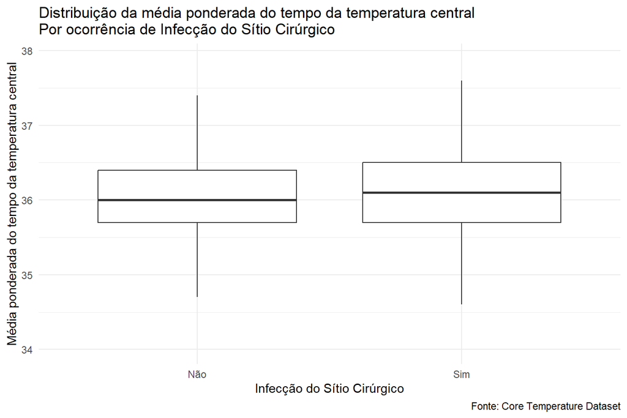

```r
p1<- ggplot(data= temperature_data,
            aes(x = any_infection, y = twa_temp)) +
  geom_boxplot(outlier.shape = NA) +
  labs(title = "Distribuição da média ponderada do tempo da temperatura central\nPor ocorrência de Infecção do Sítio Cirúrgico",
         y = "Média ponderada do tempo da temperatura central",
         x = "Infecção do Sítio Cirúrgico",
         caption = "Fonte: Core Temperature Dataset") +
  theme_minimal()


p1
```

### 2.3.4 Exercicio M5.3 Modelos

#### Exercicio M5.3.1 Univariado

Crie um modelo de regressão logística para avaliar o efeito da temperatura no risco de ISCs (AnyInfection).

1. Criar modelo no objeto model_logit_uni
2. Criar tabela com dados da regressão no objeto model_logit_uni_tidy

```r
model_logit_uni <- glm(
  any_infection ~ twa_temp,  # Definir a fórmula do modelo
  family = "binomial",                   # Especificar a função de ligação binomial para resposta binária
  data = temperature_data                            # Usar o conjunto de dados 'hd'
)

# Utilizar a função tidy para criar um resumo do modelo
# 'exponentiate = TRUE' transforma os coeficientes em razões de probabilidades
# 'conf.int = TRUE' inclui os intervalos de confiança
model_logit_uni_tidy <- tidy(model_logit_uni, exponentiate = TRUE, conf.int = TRUE)
model_logit_uni_tidy
```

```
# A tibble: 2 × 7
  term          estimate std.error statistic     p.value     conf.low conf.high
  <chr>            <dbl>     <dbl>     <dbl>       <dbl>        <dbl>     <dbl>
1 (Intercept) 0.00000759    2.21       -5.32 0.000000102 0.0000000981  0.000578
2 twa_temp    1.32          0.0614      4.52 0.00000625  1.17          1.49
```

#### Exercicio M5.3.2 Múltiplo

Crie um modelo de regressão logística para avaliar o efeito da temperatura no risco de ISCs (AnyInfection) ajustado para Age, FEMALE, BMI, CharlsonScore e CHF.

1. Criar modelo no objeto model_logit_multi
2. Criar tabela com dados da regressão no objeto model_logit_multi_tidy

```r
# Criar um modelo de regressão logística para prever a ocorrência de risco de ISCs (AnyInfection).
model_logit_multi <- glm(
  any_infection ~ twa_temp+
                       age+
                    female+
                       bmi+
            charlson_score+
                       chf,  # Definir a fórmula do modelo
  family = "binomial",                   # Especificar a função de ligação binomial para resposta binária
  data = temperature_data                            # Usar o conjunto de dados 'hd'
)

# Utilizar a função tidy para criar um resumo do modelo
# 'exponentiate = TRUE' transforma os coeficientes em razões de probabilidades
# 'conf.int = TRUE' inclui os intervalos de confiança
model_logit_multi_tidy <- tidy(model_logit_multi, exponentiate = TRUE, conf.int = TRUE)
  # Modificar os nomes dos termos para torná-los mais legíveis
  # mutate(
  #   term = case_when(
  #     term == "(Intercept)" ~ "Intercept",
  #     term == "twa_temp" ~ "Temperatura Média", # Renomear '(Intercept)' para 'Intercept'
  #     term == "age" ~ "Idade",                 # Renomear 'age' para 'Age'
  #     term == "female" ~ "Sexo",
  #     term == "bmi" ~ "IMC",
  #     term == "charlson_score" ~ "Score de Charlson",
  #     term == "chf" ~ "Insuficiência Cardíaca",
  #   )
  # )
```

#### Exercicio M5.3.3 Performance

Compare os dois modelos em termos de performance.

```r
#Usando o pacote performance
# Verificar as suposições do modelo de regressão linear 'model3'
# Esta função verifica várias suposições importantes, como normalidade dos resíduos, homocedasticidade, entre outras.
# check_model(model_logit_multi)

#Usando o pacote performance

model_performance(model_logit_uni)
```

```
# Indices of model performance

AIC      |     AICc |      BIC | Tjur's R2 |  RMSE | Sigma | Log_loss | Score_log | Score_spherical |   PCP
-----------------------------------------------------------------------------------------------------------
6463.713 | 6463.714 | 6477.664 |     0.003 | 0.349 | 0.904 |    0.408 |  -173.094 |       1.273e-04 | 0.756
```

```r
model_performance(model_logit_multi)
```

```
# Indices of model performance

AIC      |     AICc |      BIC | Tjur's R2 |  RMSE | Sigma | Log_loss | Score_log | Score_spherical |   PCP
-----------------------------------------------------------------------------------------------------------
6445.134 | 6445.148 | 6493.964 |     0.006 | 0.349 | 0.902 |    0.407 |  -173.472 |       1.445e-04 | 0.757
```

Resposta: O AIC é mais baixo para model_logit_multi, sugerindo que tem um melhor ajuste aos dados com menos penalizações pelo número de parâmetros no modelo. O BIC mais baixo para model_logit_uni sugere que pode ser o modelo mais apropriado ao considerar a complexidade do modelo pois esta métrcia penaliza complexidade. O Tjur’s R2, uma medida de ajuste do modelo, é maior para model_logit_multi, indicando um poder discriminatório ligeiramente melhor, mas ambos não se afastam muito do zero indicando uma baixa capacidade preditiva de ambos os modelos. Ambos os modelos têm um PCP quase idêntico, indicando um desempenho preditivo geral similar. Apesar de melhor em termos preditivos, o modelo multivariado é mais complexo.

### 2.3.5 Exercicio M5.4 Tabelas de Regressão

Crie uma tabela com os OR, p-value e Confidence Intervals do modelo construído em 5.3.2. Exporte a tabela criada para Word.

1. O objeto tabela deve-se chamar tbl_multi

```r
# Criar uma tabela com o pacote gt a partir do resumo do modelo 'model4_tidy'
tbl_multi <-
  gt(model_logit_multi_tidy) |>
  # Adicionar um cabeçalho com título e subtítulo
  tab_header(
    title = md("**Modelo de Risco para Infecção do Sítio Cirúrgico**"),
    subtitle = "Por Média ponderada do tempo da temperatura central Idade, Sexo, BMI, Score Charlson, Tipo de cirurgia"
  ) |>
  # Adicionar uma nota de rodapé com a fonte dos dados
  tab_source_note(
    source_note = md("Fonte: Core Temperature Dataset")
  ) |>
  # Renomear os rótulos das colunas
  cols_label(
    term = "Preditor",
    estimate = "Razão de Probabilidades (OR)",
    p.value = "Valor p",
    conf.low = "IC Inferior",
    conf.high = "IC Superior"
  ) |>
  # Formatar todos os números com três casas decimais
  fmt_number(decimals = 3) |>
  # Aplicar um estilo visual às células dos rótulos das colunas
  tab_style(
    style = cell_fill(color = "grey95"),
    locations = list(cells_column_labels())
  ) |>
  # Alinhar o cabeçalho da tabela à esquerda
  opt_align_table_header(align = "left")

# Mostrar a tabela gt
tbl_multi
```

**Modelo de Risco para Infecção do Sítio Cirúrgico**

| Preditor | Razão de Probabilidades (OR) | std.error | statistic | Valor p | IC Inferior | IC Superior |
| --- | --- | --- | --- | --- | --- | --- |
| (Intercept) | 0.000 | 2.282 | −4.732 | 0.000 | 0.000 | 0.002 |
| twa_temp | 1.268 | 0.063 | 3.768 | 0.000 | 1.121 | 1.435 |
| age | 0.997 | 0.002 | −1.257 | 0.209 | 0.993 | 1.002 |
| female | 0.944 | 0.065 | −0.883 | 0.377 | 0.832 | 1.072 |
| bmi | 1.022 | 0.005 | 4.247 | 0.000 | 1.011 | 1.032 |
| charlson_score | 1.025 | 0.017 | 1.420 | 0.156 | 0.990 | 1.060 |
| chf | 1.408 | 0.166 | 2.057 | 0.040 | 1.008 | 1.937 |

Fonte: Core Temperature Dataset

```r
gtsave(
  tbl_multi,
  "tabela.docx"
)
```

## 2.4 FIM

# 3 Validation - NÃO ALTERAR

```
[1] ":) Objeto 'tabela1' criado com sucesso"
```

```
[1] ":) Objeto 'p1' criado com sucesso"
[1] ":) Objeto 'p1' com variável correta no X"
[1] ":) Objeto 'p1' com variável correta no Y"
```

```
[1] ":) Objeto 'model_logit_uni' criado com sucesso"
```

```
[1] ":) Objeto 'model_logit_uni_tidy' criado com sucesso"
```

```
[1] ":) Objeto 'model_logit_multi' criado com sucesso"
```

```
[1] ":) Objeto 'model_logit_multi_tidy' criado com sucesso"
```

```
[1] ":) Objeto 'tbl_multi' criado com sucesso"
```

[interactive chart not shown]

## Notas de rodapé

[^1]: *Fonte: The Core Temperature dataset was contributed by Ms. Jordyn Homoki, Research and Teaching Assistant, and Dr. Amy Nowacki, Associate Professor, Cleveland Clinic. Please refer to this resource as: Homoki, J. and Nowacki AS, “Core Temperature Dataset”, TSHS Resources Portal (2023). Available at https://www.causeweb.org/tshs/core-temperature/.*